# AIML_ML_Project_full_code_notebook_Final

### Pre-Pruning without class_weight=balanced

```python
# Define the parameters of the tree to iterate over
max_depth_values = np.arange(2, 7, 2)
max_leaf_nodes_values = [50, 75, 150, 250]
min_samples_split_values = [10, 30, 50, 70]

# Initialize variables to store the best model and its performance
best_estimator = None
best_score_diff = float('inf')
best_test_score = 0.0

# Iterate over all combinations of the specified parameter values
for max_depth in max_depth_values:
    for max_leaf_nodes in max_leaf_nodes_values:
        for min_samples_split in min_samples_split_values:

            # Initialize the tree with the current set of parameters
            estimator_3 = DecisionTreeClassifier(
                max_depth=max_depth,
                max_leaf_nodes=max_leaf_nodes,
                min_samples_split=min_samples_split,
                #class_weight='balanced',
                random_state=1
            )

            # Fit the model to the training data
            estimator_3.fit(X_train, y_train)

            # Make predictions on the training and test sets
            y_train_pred = estimator_3.predict(X_train)
            y_test_pred = estimator_3.predict(X_test)

            # Calculate recall scores for training and test sets
            train_recall_score = recall_score(y_train, y_train_pred)
            test_recall_score = recall_score(y_test, y_test_pred)

            # Calculate the absolute difference between training and test recall scores
            score_diff = abs(train_recall_score - test_recall_score)

            # Update the best estimator and best score if the current one has a smaller score difference
            if (score_diff < best_score_diff) & (test_recall_score > best_test_score):
                best_score_diff = score_diff
                best_test_score = test_recall_score
                best_estimator = estimator_3

# Print the best parameters
print("Best parameters found:")
print(f"Max depth: {best_estimator.max_depth}")
print(f"Max leaf nodes: {best_estimator.max_leaf_nodes}")
print(f"Min samples split: {best_estimator.min_samples_split}")
print(f"Best test recall score: {best_test_score}")
```

```
Best parameters found:
Max depth: 6
Max leaf nodes: 50
Min samples split: 10
Best test recall score: 0.9513888888888888
```

```python
# Fit the best algorithm to the data.
estimator_3 = best_estimator
estimator_3.fit(X_train, y_train)
```

```
DecisionTreeClassifier(max_depth=6, max_leaf_nodes=50, min_samples_split=10,
                       random_state=1)
```

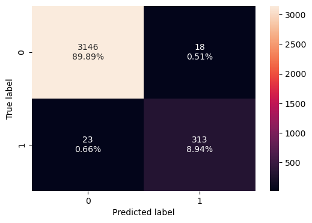

```python
confusion_matrix_sklearn(estimator_3, X_train, y_train)
```

```python
decision_tree_tune_cw_perf_train = model_performance_classification_sklearn(estimator_3, X_train, y_train)
decision_tree_tune_cw_perf_train
```

|  | Accuracy | Recall | Precision | F1 |
| --- | --- | --- | --- | --- |
| 0 | 0.988286 | 0.931548 | 0.945619 | 0.938531 |

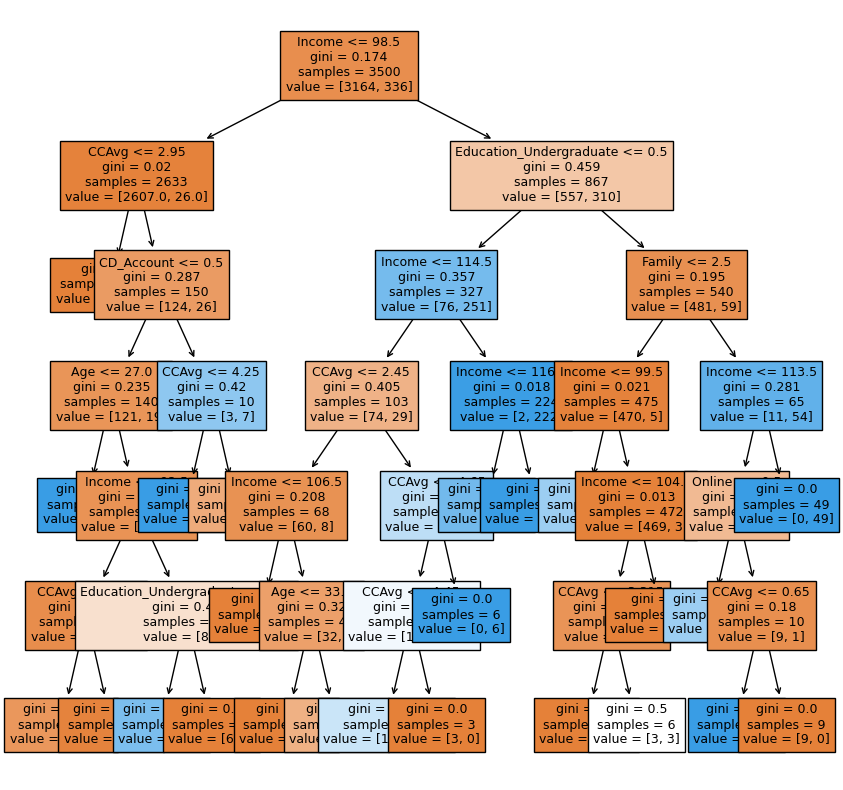

```python
plt.figure(figsize=(10, 10))
out = tree.plot_tree(
    estimator_3,
    feature_names=feature_names,
    filled=True,
    fontsize=9,
    node_ids=False,
    class_names=None,
)
# below code will add arrows to the decision tree split if they are missing
for o in out:
    arrow = o.arrow_patch
    if arrow is not None:
        arrow.set_edgecolor("black")
        arrow.set_linewidth(1)
plt.show()
```

```python
# Text report showing the rules of a decision tree -

print(tree.export_text(estimator_3, feature_names=feature_names, show_weights=True))
```

```
|--- Income <= 98.50
|   |--- CCAvg <= 2.95
|   |   |--- weights: [2483.00, 0.00] class: 0
|   |--- CCAvg >  2.95
|   |   |--- CD_Account <= 0.50
|   |   |   |--- Age <= 27.00
|   |   |   |   |--- weights: [0.00, 2.00] class: 1
|   |   |   |--- Age >  27.00
|   |   |   |   |--- Income <= 92.50
|   |   |   |   |   |--- CCAvg <= 3.65
|   |   |   |   |   |   |--- weights: [57.00, 10.00] class: 0
|   |   |   |   |   |--- CCAvg >  3.65
|   |   |   |   |   |   |--- weights: [56.00, 1.00] class: 0
|   |   |   |   |--- Income >  92.50
|   |   |   |   |   |--- Education_Undergraduate <= 0.50
|   |   |   |   |   |   |--- weights: [2.00, 6.00] class: 1
|   |   |   |   |   |--- Education_Undergraduate >  0.50
|   |   |   |   |   |   |--- weights: [6.00, 0.00] class: 0
|   |   |--- CD_Account >  0.50
|   |   |   |--- CCAvg <= 4.25
|   |   |   |   |--- weights: [0.00, 6.00] class: 1
|   |   |   |--- CCAvg >  4.25
|   |   |   |   |--- weights: [3.00, 1.00] class: 0
|--- Income >  98.50
|   |--- Education_Undergraduate <= 0.50
|   |   |--- Income <= 114.50
|   |   |   |--- CCAvg <= 2.45
|   |   |   |   |--- Income <= 106.50
|   |   |   |   |   |--- weights: [28.00, 0.00] class: 0
|   |   |   |   |--- Income >  106.50
|   |   |   |   |   |--- Age <= 33.50
|   |   |   |   |   |   |--- weights: [11.00, 0.00] class: 0
|   |   |   |   |   |--- Age >  33.50
|   |   |   |   |   |   |--- weights: [21.00, 8.00] class: 0
|   |   |   |--- CCAvg >  2.45
|   |   |   |   |--- CCAvg <= 4.65
|   |   |   |   |   |--- CCAvg <= 4.45
|   |   |   |   |   |   |--- weights: [11.00, 15.00] class: 1
|   |   |   |   |   |--- CCAvg >  4.45
|   |   |   |   |   |   |--- weights: [3.00, 0.00] class: 0
```

[output cut: 15 more lines]

```
|   |   |   |   |   |--- CCAvg >  3.31
|   |   |   |   |   |   |--- weights: [3.00, 3.00] class: 0
|   |   |   |   |--- Income >  104.50
|   |   |   |   |   |--- weights: [449.00, 0.00] class: 0
|   |   |--- Family >  2.50
|   |   |   |--- Income <= 113.50
|   |   |   |   |--- Online <= 0.50
|   |   |   |   |   |--- weights: [2.00, 4.00] class: 1
|   |   |   |   |--- Online >  0.50
|   |   |   |   |   |--- CCAvg <= 0.65
|   |   |   |   |   |   |--- weights: [0.00, 1.00] class: 1
|   |   |   |   |   |--- CCAvg >  0.65
|   |   |   |   |   |   |--- weights: [9.00, 0.00] class: 0
|   |   |   |--- Income >  113.50
|   |   |   |   |--- weights: [0.00, 49.00] class: 1
```

```python
# importance of features in the tree building ( The importance of a feature is computed as the
# (normalized) total reduction of the criterion brought by that feature. It is also known as the Gini importance )

print(
    pd.DataFrame(
        estimator_3.feature_importances_, columns=["Imp"], index=X_train.columns
    ).sort_values(by="Imp", ascending=False)
)
```

```
                              Imp
Income                   0.452217
Education_Undergraduate  0.328215
Family                   0.139980
CCAvg                    0.056668
CD_Account               0.010814
Age                      0.007724
Online                   0.004382
Securities_Account       0.000000
CreditCard               0.000000
Mortgage                 0.000000
ZIPCode_92               0.000000
ZIPCode_93               0.000000
ZIPCode_94               0.000000
ZIPCode_95               0.000000
ZIPCode_96               0.000000
ZIPCode_97               0.000000
Education_Professional   0.000000
ZIPCode_91               0.000000
```

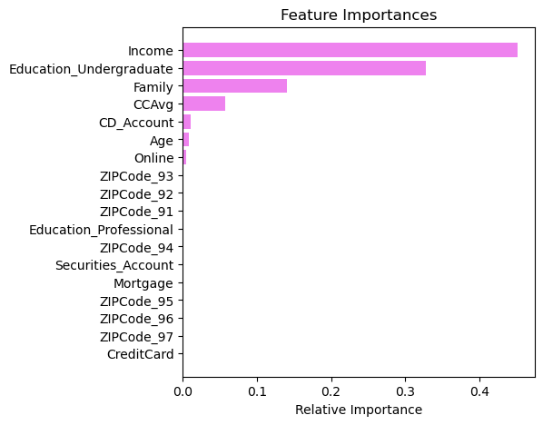

```python
importances = estimator_3.feature_importances_
indices = np.argsort(importances)

plt.figure(figsize=(5, 5))
plt.title("Feature Importances")
plt.barh(range(len(indices)), importances[indices], color="violet", align="center")
plt.yticks(range(len(indices)), [feature_names[i] for i in indices])
plt.xlabel("Relative Importance")
plt.show()
```

##### Observation :

Income, Education_Undergraduate, Family, CCAvg and CD_Account are the most important features affecting the target variable

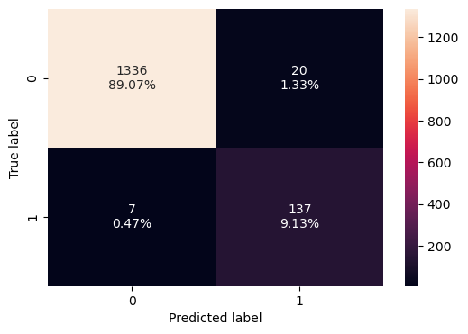

```python
confusion_matrix_sklearn(estimator_3, X_test, y_test)
```

```python
decision_tree_tune_cw_perf_test = model_performance_classification_sklearn(estimator_3, X_test, y_test)
decision_tree_tune_cw_perf_test
```

|  | Accuracy | Recall | Precision | F1 |
| --- | --- | --- | --- | --- |
| 0 | 0.982 | 0.951389 | 0.872611 | 0.910299 |

##### Observation :

Model is able to generalize well on the test set as all metrics are comparable with training set  
The False positives and False Negatives are less than 2% which is pretty good  
However, this model did not use the class_weight=balanced attribute which indicates the dataset is imbalanced

## Post-pruning

```python
clf = DecisionTreeClassifier(random_state=1, class_weight="balanced")
path = clf.cost_complexity_pruning_path(X_train, y_train)
ccp_alphas, impurities = path.ccp_alphas, path.impurities
```

```python
pd.DataFrame(path)
```

|  | ccp_alphas | impurities |
| --- | --- | --- |
| 0 | 0.000000e+00 | -2.402150e-16 |
| 1 | 1.052677e-19 | -2.401097e-16 |
| 2 | 1.543926e-18 | -2.385658e-16 |
| 3 | 1.543926e-18 | -2.370219e-16 |
| 4 | 2.947495e-18 | -2.340744e-16 |
| 5 | 5.947623e-18 | -2.281267e-16 |
| 6 | 6.158159e-18 | -2.219686e-16 |
| 7 | 1.652118e-17 | -2.054474e-16 |
| 8 | 1.945347e-16 | -1.091275e-17 |
| 9 | 3.072237e-16 | 2.963109e-16 |
| 10 | 5.099166e-16 | 8.062275e-16 |
| 11 | 1.526252e-04 | 3.052503e-04 |
| 12 | 1.533742e-04 | 9.187472e-04 |
| 13 | 1.539409e-04 | 1.226629e-03 |
| 14 | 1.539409e-04 | 1.534511e-03 |
| 15 | 1.567474e-04 | 1.848006e-03 |
| 16 | 1.621448e-04 | 2.172295e-03 |
| 17 | 2.105024e-04 | 2.803802e-03 |
| 18 | 2.851692e-04 | 3.374141e-03 |
| 19 | 2.857143e-04 | 3.659855e-03 |
| 20 | 2.923583e-04 | 3.952213e-03 |
| 21 | 2.927400e-04 | 4.830433e-03 |
| 22 | 3.001200e-04 | 5.130553e-03 |
| 23 | 3.001200e-04 | 6.030914e-03 |
| 24 | 3.024084e-04 | 8.147772e-03 |
| 25 | 3.052503e-04 | 8.453023e-03 |
| 26 | 3.078818e-04 | 8.760904e-03 |
| 27 | 3.809811e-04 | 9.903848e-03 |
| 28 | 4.722795e-04 | 1.084841e-02 |
| 29 | 5.168691e-04 | 1.136528e-02 |
| 30 | 5.292740e-04 | 1.189455e-02 |
| 31 | 5.426170e-04 | 1.243717e-02 |
| 32 | 5.703384e-04 | 1.300751e-02 |
| 33 | 7.434819e-04 | 1.598143e-02 |
| 34 | 7.479316e-04 | 1.672936e-02 |
| 35 | 8.479100e-04 | 1.842518e-02 |
| 36 | 8.725869e-04 | 1.929777e-02 |
| 37 | 1.106876e-03 | 2.040465e-02 |
| 38 | 1.148851e-03 | 2.385120e-02 |
| 39 | 1.603499e-03 | 2.545470e-02 |
| 40 | 1.724472e-03 | 2.717917e-02 |
| 41 | 1.784924e-03 | 2.896410e-02 |
| 42 | 1.793666e-03 | 3.434509e-02 |
| 43 | 2.032423e-03 | 3.840994e-02 |
| 44 | 2.186703e-03 | 4.059664e-02 |
| 45 | 2.962264e-03 | 4.355891e-02 |
| 46 | 5.593362e-03 | 4.915227e-02 |
| 47 | 5.872977e-03 | 5.502525e-02 |
| 48 | 6.618052e-03 | 6.164330e-02 |
| 49 | 6.913702e-03 | 6.855700e-02 |
| 50 | 7.489143e-03 | 7.604614e-02 |
| 51 | 2.867322e-02 | 1.047194e-01 |
| 52 | 5.478478e-02 | 2.142889e-01 |
| 53 | 2.857111e-01 | 5.000000e-01 |

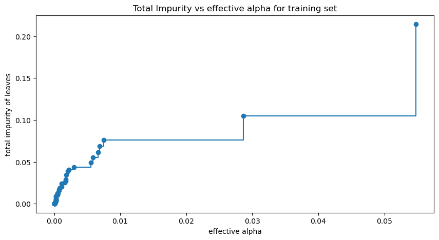

```python
fig, ax = plt.subplots(figsize=(10, 5))
ax.plot(ccp_alphas[:-1], impurities[:-1], marker="o", drawstyle="steps-post")
ax.set_xlabel("effective alpha")
ax.set_ylabel("total impurity of leaves")
ax.set_title("Total Impurity vs effective alpha for training set")
plt.show()
```